# Analysis of human Frizzled receptor mutants

# 1 Description

This R notebook attempts the analysis of an array of mutants in one of the 10 human Frizzled receptors, Frizzled 5 (FZD5). Each mutant was predicted to alter receptor function based on computational structure/function analysis. The mutants are expected to either promote or repress receptor activation through Wnt binding. The canonical signaling cascade is: Wnt –> FZDR –> DVL –> GSK-3b –> APC –> beta-catenin –> gene regulation.

Different types of experimental data ares available:

- `data/input/FZD_mutations.csv` - original GPCR computer model prediction of mutant effects
- `data/input/DVL_shift.csv` - Dishevelled (DVL) shift assay. Measures the phosphorylation status of the intracellular signal protein DVL through the FZD5 receptor (and its mutants)
- `data/input/DEP_recruitment.csv` - DEP recruitment assay. Measurement of recruitment of DEP as an isolated domain of DVL via BRET, that indicates proximity of the two proteins.
- `data/input/TOPFlash.csv` - Top flash assay. Luciferase-based gene reporter assay to assess the activity of the WNT/β-catenin signaling branch.
- `data/input/GqIns4A.csv` - An assay for G protein signaling to assess constitutive activation between Gq and FZD5. Uses an engineered G-alpha subunit.
- `data/input/bretmax` - Maximal BRET values from BRET readout between FZD5 and DEP.
- `data/input/bretzero` - Minimal BRET values from BRET readout between FZD5 and DEP.

# 2 Prerequisites

```r
if (!"latticetools" %in% rownames(installed.packages())) {
  devtools::install_github("m-jahn/lattice-tools")
}
if (!"Rtools" %in% rownames(installed.packages())) {
  devtools::install_github("m-jahn/R-tools")
}
```

Load required packages.

```r
suppressPackageStartupMessages({
  library(tidyverse)
  library(ggrepel)
  library(lattice)
  library(latticeExtra)
  library(latticetools)
  library(scales)
  library(dendextend)
  library(factoextra)
  library(vegan)
})
```

Define global figure style, default colors, and other optional parameters.

```r
# custom ggplot2 theme that is reused for all later plots
custom_colors = c("#E7298A", "#66A61E", "#E6AB02", "#7570B3", "#B3B3B3", "#1B9E77", "#D95F02", "#A6761D")
custom_range <- function(n = 5) {colorRampPalette(custom_colors[c(1,5,2)])(n)}
custom_cluster <- c("#0075B5", "#F5AF1B", "#82549D")
```

# 3 Data import

Import an annotation file that matches regular AA postions to Ballasteros-Weinstein annotation for GPCR receptors. In this annotation, each AA is denominated by one digit representing one of 7 TM-helices, and a positional code representing the distance to the most conserved AA in that helix with (position `.50`). For example, `A 4.48` is an Alanin residue in TM domain 4, 2 residues away from the most conserved residue.

```r
df_nom <- read_csv("../data/input/BallesteroNom.csv", col_types = cols()) %>%
  mutate(mutation_bwform = paste0(
    str_sub(mutation_bw, 1, 1), "^'",
    str_extract(mutation_bw, "[0-9]+\\.[0-9]+"), "'*",
    str_extract(mutation_bw, ".$")
  )) %>%
  add_row(mutation = "WT", mutation_bw = "WT", mutation_bwform = "WT")

head(df_nom)
```

| mutation | mutation_bw | mutation_bwform |
| --- | --- | --- |
| T253A | T1.50A | T^'1.50'*A |
| T256A | T1.53A | T^'1.53'*A |
| Y266A | Y2.39A | Y^'2.39'*A |
| C277A | C2.50A | C^'2.50'*A |
| Y278A | Y2.51A | Y^'2.51'*A |
| F319A | F3.29A | F^'3.29'*A |

Load raw data tables.

```r
# load main table with processed sequencing data
df_dep_recr <- read_csv("../data/input/DEP_recruitment.csv", col_types = cols()) %>%
  left_join(df_nom, by = "mutation") %>%
  mutate(mutation_bw = factor(mutation_bw, unique(mutation_bw)))

df_dvl_shift <- read_csv("../data/input/DVL_shift.csv", col_types = cols()) %>%
  left_join(df_nom, by = "mutation") %>%
  mutate(mutation_bw = factor(mutation_bw, unique(mutation_bw)))

df_top_flash <- read_csv("../data/input/TOPFlash.csv", col_types = cols()) %>%
  left_join(df_nom, by = "mutation") %>%
  mutate(mutation_bw = factor(mutation_bw, unique(mutation_bw)))

df_gq4a <- read_csv("../data/input/GqIns4A.csv", col_types = cols()) %>%
  left_join(df_nom, by = "mutation") %>%
  mutate(mutation_bw = factor(mutation_bw, unique(mutation_bw)))

df_bret0 <- read_csv("../data/input/BRET0_assay.csv", col_types = cols()) %>%
  left_join(df_nom, by = "mutation") %>%
  mutate(mutation_bw = factor(mutation_bw, unique(mutation_bw)))
```

# 4 Exploratory analysis

## 4.1 DEP recruitment

BRET values for all mutants.

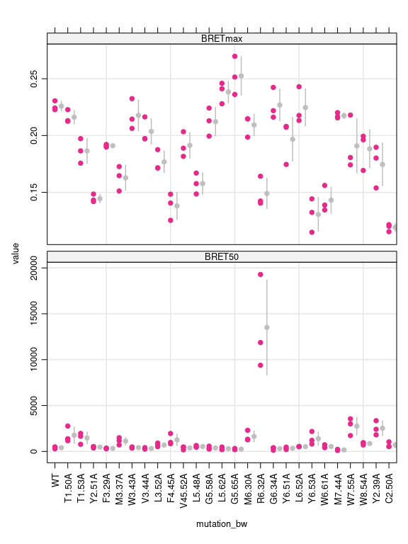

```r
xyplot(value ~ mutation_bw | type, df_dep_recr,
  par.settings = custom.colorblind(),
  between = list(x = 0.5, y = 0.5),
  layout = c(1,2),
  scales = list(alternating = FALSE, x = list(rot = 90), y = list(relation = "free")),
  panel = function(x, y, ...) {
    panel.grid(h = -1, v = -1, col = grey(0.9))
    panel.errbars(as.numeric(x)+0.5, y, col = grey(0.75), ewidth = 0, ...)
    panel.xyplot(x, y, ...)
  }
)
```

BRET50 and BRETmax value correlation for all mutants. There is no real correlation.

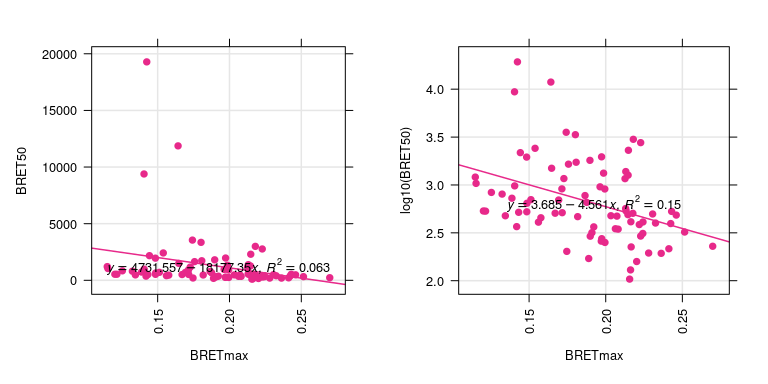

```r
plot_bret_cor1 <- df_dep_recr %>%
  pivot_wider(names_from = "type", values_from = "value") %>%
  xyplot(BRET50 ~ BRETmax, .,
    par.settings = custom.colorblind(),
    between = list(x = 0.5, y = 0.5),
    title = "linear BRET 50",
    scales = list(alternating = FALSE, x = list(rot = 90)),
    panel = function(x, y, ...) {
      panel.grid(h = -1, v = -1, col = grey(0.9))
      panel.xyplot(x, y, ...)
      panel.lmlineq(x, y, r.squared = TRUE, fontfamily = "FreeSans", ...)
    }
  )

plot_bret_cor2 <- df_dep_recr %>%
  pivot_wider(names_from = "type", values_from = "value") %>%
  xyplot(log10(BRET50) ~ BRETmax, .,
    par.settings = custom.colorblind(),
    between = list(x = 0.5, y = 0.5),
    title = "log10 BRET 50",
    scales = list(alternating = FALSE, x = list(rot = 90)),
    panel = function(x, y, ...) {
      panel.grid(h = -1, v = -1, col = grey(0.9))
      panel.xyplot(x, y, ...)
      panel.lmlineq(x, y, r.squared = TRUE, fontfamily = "FreeSans", ...)
    }
  )

print(plot_bret_cor1, split = c(1,1,2,1), more = TRUE)
print(plot_bret_cor2, split = c(2,1,2,1))
```

The correlation and the distribution of the data improves when BRET50 data is log-transformed. Although more a cosmetic approach, we log10-transform the BRET50 data to make more use of it for now.

```r
df_dep_recr <- df_dep_recr %>%
  mutate(value = case_when(type == "BRET50" ~ log10(value), TRUE ~ value))
```

## 4.2 DVL shift assay

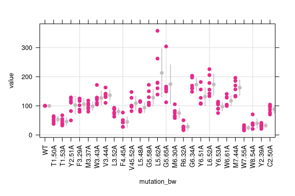

```r
df_dvl_shift %>%
  xyplot(value ~ mutation_bw, .,
    par.settings = custom.colorblind(),
    between = list(x = 0.5, y = 0.5),
    scales = list(alternating = FALSE, x = list(rot = 90)),
    panel = function(x, y, ...) {
      panel.grid(h = -1, v = -1, col = grey(0.9))
      panel.errbars(as.numeric(x)+0.5, y, col = grey(0.75), ewidth = 0, ...)
      panel.xyplot(x, y, ...)
    }
  )
```

## 4.3 Top flash assay

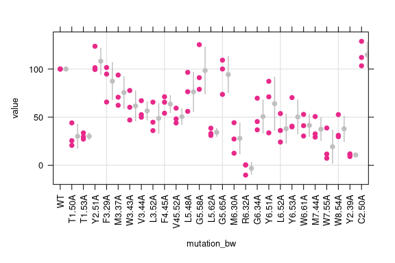

```r
df_top_flash %>%
  xyplot(value ~ mutation_bw, .,
    par.settings = custom.colorblind(),
    between = list(x = 0.5, y = 0.5),
    scales = list(alternating = FALSE, x = list(rot = 90)),
    panel = function(x, y, ...) {
      panel.grid(h = -1, v = -1, col = grey(0.9))
      panel.errbars(as.numeric(x)+0.5, y, col = grey(0.75), ewidth = 0, ...)
      panel.xyplot(x, y, ...)
    }
  )
```

## 4.4 GQ 4-alanin insertion

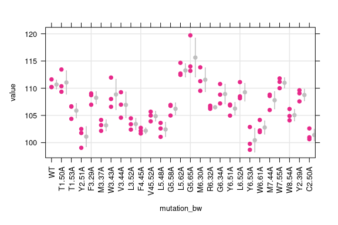

```r
df_gq4a %>%
  xyplot(value ~ mutation_bw, .,
    par.settings = custom.colorblind(),
    between = list(x = 0.5, y = 0.5),
    scales = list(alternating = FALSE, x = list(rot = 90)),
    panel = function(x, y, ...) {
      panel.grid(h = -1, v = -1, col = grey(0.9))
      panel.errbars(as.numeric(x)+0.5, y, col = grey(0.75), ewidth = 0, ...)
      panel.xyplot(x, y, ...)
    }
  )
```

## 4.5 BRET-zero assay (conformation sensor)

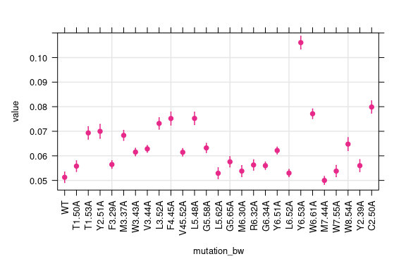

```r
df_bret0 %>%
  xyplot(value ~ mutation_bw, .,
    errors = .[["stdev"]],
    par.settings = custom.colorblind(),
    between = list(x = 0.5, y = 0.5),
    scales = list(alternating = FALSE, x = list(rot = 90)),
    panel = function(x, y, errors, ...) {
      panel.grid(h = -1, v = -1, col = grey(0.9))
      panel.errbars(x, y, error_margin = errors, ewidth = 0, ...)
    }
  )
```

## 4.6 Combine assays and check correlation

There are different numbers of replicates. We need to summarize all tables to mean +/- standard deviation and then combine them.

```r
df_combined <- bind_rows(
  df_dep_recr,
  df_dvl_shift,
  df_top_flash,
  df_gq4a,
  df_bret0)

df_summary <- df_combined %>%
  group_by(type, n_mutation, mutation, mutation_bw, mutation_bwform) %>%
  summarize(.groups = "drop",
    mean_value = mean(value, na.rm = TRUE),
    sd_value = sd(value, na.rm = TRUE)
  )

head(df_summary)
```

| type | n_mutation | mutation | mutation_bw | mutation_bwform | mean_value | sd_value |
| --- | --- | --- | --- | --- | --- | --- |
| BRET0 | 0 | WT | WT | WT | 0.05126 | NA |
| BRET0 | 1 | T253A | T1.50A | T^'1.50'*A | 0.05581 | NA |
| BRET0 | 2 | T256A | T1.53A | T^'1.53'*A | 0.06933 | NA |
| BRET0 | 3 | Y278A | Y2.51A | Y^'2.51'*A | 0.06998 | NA |
| BRET0 | 4 | F319A | F3.29A | F^'3.29'*A | 0.05647 | NA |
| BRET0 | 6 | M327A | M3.37A | M^'3.37'*A | 0.06834 | NA |

Check pairwise correlation of variables. Notable correlations:

- TOPFlash is negatively correlated with BRET50
- GQ-4A insertion is negatively correlated with BRET0 and positively with BRETmax
- DVL shift assay is negatively correlated with BRET50 and positively with BRETmax
- BRETmax is negatively correlated with BRET0

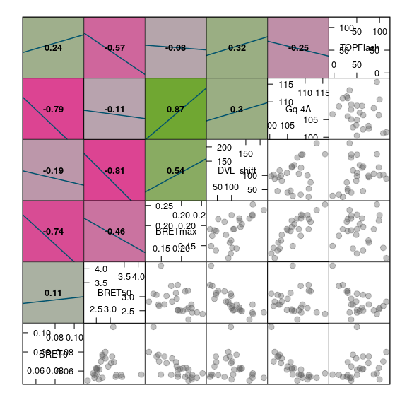

```r
fig_splom <- df_summary %>% select(-sd_value) %>%
  pivot_wider(values_from = mean_value, names_from = type) %>%
  select(matches("BRET|DVL|GQ|TOP")) %>%
  custom_splom(pch = 19, cex = 1, col = grey(0.4, 0.4),
    col_palette = custom_range(10))

print(fig_splom)
```

- Export figure
- Draw extra legend using `draw.colorkey` from `lattice::levelplot()` function.

```r
svg("../figures/figure_splom.svg", width = 6, height = 6)
print(fig_splom)
dev.off()
```

```r
svg("../figures/figure_splom_legend.svg", width = 2, height = 3)
```

```r
grid::grid.newpage()
grid::pushViewport(
  grid::viewport(x = 0.5, y = 0.5,
    width = 0.9, height = 0.9
  )
)
```

```r
grid::grid.draw(
  lattice::draw.colorkey(key = list(
    space = "right",
    col = custom_range(11),
    at = seq(-1, 1, 0.2),
    width = 1
  ))
)
dev.off()
```

Which mutations are most like each other in their behavior? We need to cluster mutations by similarity of experimental results. In order to make different variables comparable, we rescale every var to a range between zero and one.

```r
mat_summary <- df_summary %>%
  select(-sd_value, -mutation, -mutation_bwform) %>%
  pivot_wider(values_from = mean_value, names_from = type) %>%
  select(matches("^mutation|BRET|DVL|GQ|TOP")) %>%
  column_to_rownames(var = "mutation_bw") %>%
  as.matrix %>% apply(2, rescale)

# create cluster for reordering
mat_cluster <- mat_summary %>% dist %>% hclust(method = "ward.D2")
mat_heatmap <- mat_summary[order.dendrogram(as.dendrogram(mat_cluster)), c(1,2,3,5,4,6)]
```

How many clusters are optimal? Use silhouette analysis to determine optimal number of clusters.

```r
# devtools::install_github("m-jahn/R-tools")
silhouette_result <- Rtools::silhouette_analysis(mat = mat_heatmap, n_repeats = 20)
n_clusters <- silhouette_result$optimal_n_clust
paste("Optimal number of clusters is: ", n_clusters)
```

```
[1] "Optimal number of clusters is:  3"
```

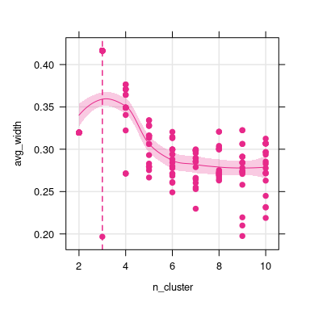

```r
xyplot(avg_width ~ n_cluster,
  silhouette_result$data_summary,
  par.settings = custom.colorblind(),
  panel = function(x, y, ...) {
    panel.grid(h = -1, v = -1, col = grey(0.9))
    panel.xyplot(x, y, ...)
    panel.smoother(x, y, ...)
    panel.abline(v = n_clusters, lty = 2)
  }
)
```

Heatmap and similarity dendrogram.

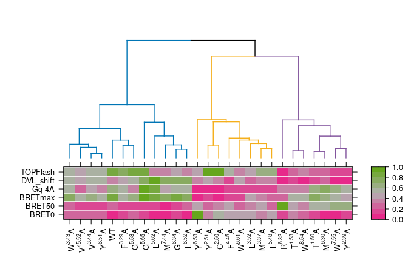

```r
# reorder dendrogram leaves a bit
dend_new_ord <- c(1:12, 20:27,13:19)
format_labels <- function(lab) {unname(deframe(df_nom[2:3])[lab])}

plot_heatmap <- levelplot(mat_heatmap[dend_new_ord, ],
  par.settings = custom.colorblind(),
  col.regions = custom_range(10),
  at = seq(0, 1, 0.1), aspect = "fill",
  xlab = "", ylab = "",
  scales = list(x = list(rot = 90,
    labels = parse(text = format_labels(
      rownames(mat_heatmap[dend_new_ord, ])))
    )),
  panel = function(x, y, z, ...) {
    panel.levelplot(x, y, z, ...)
    panel.abline(h = 1:ncol(mat_heatmap)+0.5, col = "white", lwd = 1.5)
  }
)

plot_cluster_dend <- mat_cluster %>% as.dendrogram %>%
  rotate(dend_new_ord) %>%
  set("branches_k_col", custom_cluster, k = n_clusters) %>%
  set("branches_lwd", 0.5) %>%
  as.ggdend %>%
  ggplot(labels = FALSE)

gridExtra::grid.arrange(
  # coords for unit: top, right, bottom, left
  plot_cluster_dend +
    theme(plot.margin = unit(c(0.25, 0.118, -0.28, 0.132),"npc")),
  plot_heatmap,
  nrow = 2
)
```

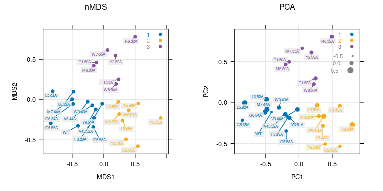

```r
# set a seed to obtain same pattern for stochastic methods
set.seed(123)

# run nMDS analysis
NMDS <- mat_heatmap %>% dist %>% metaMDS(trace = 0)
df_nmds <- NMDS$points %>% as_tibble(rownames = "mutation") %>%
  left_join(by = "mutation",
    enframe(cutreeord(mat_cluster, k = n_clusters), "mutation", "cluster")) %>%
  mutate(cluster = recode(cluster, `2` = 3, `3` = 2, `1` = 1))

plot_nmds <- xyplot(MDS2 ~ MDS1, df_nmds,
    groups = cluster, par.settings = custom.colorblind(),
    col = custom_cluster,
    aspect = 1, main = "nMDS", label = df_nmds$mutation,
    panel = function(x, y, label, ...) {
      panel.grid(h = -1, v = -1, col = grey(0.9))
      panel.xyplot(x, y, ...)
      panel.key(..., cex = 0.7, corner = c(0.98, 0.98))
      panel.repellabels(x, y, labels = label, cex = 0.5, draw_box = TRUE,
        box_fill = grey(0.9, alpha = 0.7), ...)
    }
  )

# run PCA analysis
pca_result <- prcomp(mat_heatmap)
df_PCA <- pca_result$x %>%
  as_tibble(rownames = "mutation") %>%
  left_join(by = "mutation",
    enframe(cutreeord(mat_cluster, k = n_clusters), "mutation", "cluster")) %>%
  mutate(cluster = recode(cluster, `2` = 3, `3` = 2, `1` = 1)) %>%
  mutate(PC2 = PC2*-1)

plot_pca <- xyplot(PC2 ~ PC1, df_PCA,
    groups = cluster, z = scales::rescale(df_PCA$PC3, to = c(0.4, 1.4), from = c(-0.5,0.5)),
    par.settings = custom.colorblind(),
    col = custom_cluster,
    label = df_PCA$mutation,
    aspect = 1, main = "PCA",
    panel = function(x, y, z, label, ...) {
      panel.grid(h = -1, v = -1, col = grey(0.9))
      tactile::panel.bubbleplot(x, y, z, ...)
      panel.key(..., cex = 0.7, corner = c(0.98, 0.98))
      panel.key(labels = "-0.5", cex = 0.7, point.cex = 0.4, corner = c(0.98, 0.8), col = grey(0.5))
      panel.key(labels = " 0.0", cex = 0.7, point.cex = 0.9, corner = c(0.98, 0.74), col = grey(0.5))
      panel.key(labels = " 0.5", cex = 0.7, point.cex = 1.4, corner = c(0.98, 0.68), col = grey(0.5))
      panel.repellabels(x, y, labels = label, cex = 0.5, draw_box = TRUE,
        box_fill = grey(0.9, alpha = 0.7), ...)
    }
  )

print(plot_nmds, split = c(1,1,2,1), more = TRUE)
print(plot_pca, split = c(2,1,2,1))
```

Some details on the PCA result:

- eigenvalues measure the amount of variation retained by each principal component
- variable contribution measures the amount of variation explained by each variable

See excellent description at: http://www.sthda.com/english/articles/31-principal-component-methods-in-r-practical-guide/112-pca-principal-component-analysis-essentials/

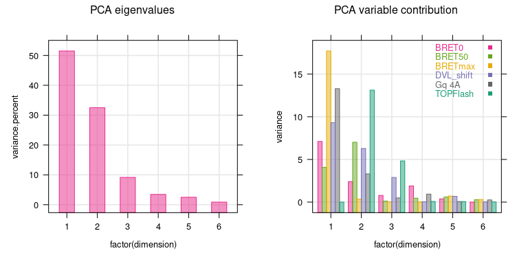

```r
plot_pca_eig <- get_eigenvalue(pca_result) %>%
  mutate(dimension = seq_along(eigenvalue)) %>%
  xyplot(variance.percent ~ factor(dimension), .,
    par.settings = custom.colorblind(),
    main = "PCA eigenvalues",
    panel = function(x, y, ...) {
      panel.grid(h = -1, v = -1, col = grey(0.9))
      panel.barplot(x, y, ...)
    }
  )

# multiply eigenvalues (variation) with variable contribution
plot_pca_var <- data.frame(as.matrix(get_pca_var(pca_result)$contrib) *
  rep(get_eigenvalue(pca_result)$variance.percent/100, each = length(pca_result$sdev))) %>%
  rownames_to_column("variable") %>%
  pivot_longer(cols = -variable, names_to = "dimension", values_to = "variance") %>%
  mutate(dimension = str_remove(dimension, "Dim.")) %>%
  xyplot(variance ~ factor(dimension), .,
    groups = variable,
    par.settings = custom.colorblind(),
    main = "PCA variable contribution",
    panel = function(x, y, ...) {
      panel.grid(h = -1, v = -1, col = grey(0.9))
      panel.barplot(x, y, beside = TRUE, ...)
      panel.key(..., pch = 15, corner = c(0.98, 0.98))
    }
  )

print(plot_pca_eig, split = c(1,1,2,1), more = TRUE)
print(plot_pca_var, split = c(2,1,2,1))
```

# 5 Structure function relationship

To plot activity data on an SVG map of a receptor, we need the custom R package `fluctuator` that can import and manipulate SVG graphic files.

```r
if (!"fluctuator" %in% rownames(installed.packages())) {
  devtools::install_github("m-jahn/fluctuator")
}
```

Import the SVG of the ‘snakeplot’, the representation of a receptor as AA residues curled in their different membrane spanning domains.

```r
library(fluctuator)

svg_fzd5 <- read_svg("../data/input/FZD5_human_snakeplot.svg")
head(svg_fzd5@summary)
```

| node_no | onclick | class | x | y | text-anchor | font-size | font-family | data-original-title | title | style | id | node_set | dominant-baseline | fill | original_title | original_x | original_y | cx | cy | r | stroke | stroke-width | fill-opacity | original_cx | original_cy | d | segment | previous_res | rx | … |
| --- | --- | --- | --- | --- | --- | --- | --- | --- | --- | --- | --- | --- | --- | --- | --- | --- | --- | --- | --- | --- | --- | --- | --- | --- | --- | --- | --- | --- | --- | --- |
| 1 | toggleLoop(".ICL1","short",false,this); | ICL1 short segment | 111.5 | 768.25 | middle | 12px | helvetica |  |  | display:none | text12 | text | NA | NA | NA | NA | NA | NA | NA | NA | NA | NA | NA | NA | NA | NA | NA | NA | NA | … |
| 2 | NA | rtext ICL1 long | 116 | 742 | middle | 16px | helvetica | M261 12.47x47 |  | display:inline | 261t | text | middle |  | M261 12.47x47 | 116 | 341 | NA | NA | NA | NA | NA | NA | NA | NA | NA | NA | NA | NA | … |
| 3 | NA | rtext ICL1 long | 110 | 761 | middle | 16px | helvetica | E262 12.48x48 |  | display:inline | 262t | text | middle |  | E262 12.48x48 | 110 | 360 | NA | NA | NA | NA | NA | NA | NA | NA | NA | NA | NA | NA | … |
| 4 | NA | rtext ICL1 long | 104 | 780 | middle | 16px | helvetica | R263 12.49x49 |  | display:inline | 263t | text | middle |  | R263 12.49x49 | 104 | 379 | NA | NA | NA | NA | NA | NA | NA | NA | NA | NA | NA | NA | … |
| 5 | NA | rtext ICL1 long | 143 | 749 | middle | 16px | helvetica | F264 12.50x50 |  | display:inline | 264t | text | middle |  | F264 12.50x50 | 143 | 348 | NA | NA | NA | NA | NA | NA | NA | NA | NA | NA | NA | NA | … |
| 6 | NA | rtext ICL1 long | 137 | 768 | middle | 16px | helvetica | R265 12.51x51 |  | display:inline | 265t | text | middle |  | R265 12.51x51 | 137 | 367 | NA | NA | NA | NA | NA | NA | NA | NA | NA | NA | NA | NA | … |

Manipulate certain amino acids by changing color. We can identify nodes by their `id` field, and make changes to fill and stroke color.

```r
get_attributes(svg_fzd5, node_attr = "id", node = "333",
  attr = c("id", "class", "fill", "stroke"))
```

| id | class | fill | stroke |
| --- | --- | --- | --- |
| 333 | TM3 rcircle | #ffffff | #000000 |

Table with mutants and associated colors.

```r
df_cluster <- df_PCA %>% filter(mutation != "WT") %>%
  select(mutation, cluster) %>%
  rename(mutation_bw = mutation) %>%
  full_join(select(df_nom, mutation, mutation_bw), by = "mutation_bw") %>%
  filter(mutation != "WT") %>%
  mutate(position = str_sub(mutation, 2, 4)) %>%
  mutate(color = custom_colors[cluster]) %>%
  mutate(color = replace_na(color, "#999999"))
```

First change color code to something more subtle for all non-mutant positions. How many AA residues do we need to change?

```r
svg_fzd5@summary %>% filter(str_detect(id, "^[0-9]+$")) %>%
  pull(id) %>% as.numeric %>% range
```

```
[1]   1 585
```

Set `fill` of non-mutant AA residues to light grey, `stroke` to white, and text label `fill` also to white.

```r
svg_fzd5_grey <- set_attributes(
  svg_fzd5, node_attr = "id",
  node = as.character(1:585)[-as.numeric(df_cluster$position)],
  attr = "fill",
  pattern = ".*",
  replacement = "#C7C7C7")

svg_fzd5_grey <- set_attributes(
  svg_fzd5_grey, node_attr = "id",
  node = as.character(1:585)[-as.numeric(df_cluster$position)],
  attr = "stroke",
  pattern = ".*",
  replacement = "#FFFFFF")

svg_fzd5_grey <- set_attributes(
  svg_fzd5_grey, node_attr = "id",
  node = paste0(as.character(1:585)[-as.numeric(df_cluster$position)], "t"),
  attr = "fill",
  pattern = ".*",
  replacement = "#FFFFFF")

# export SVG
write_svg(svg_fzd5_grey, "../data/output/FZD5_human_snakeplot_grey.svg")
```

```
[1] "../data/output/FZD5_human_snakeplot_grey.svg"
```

Set `fill` of all mutant AA residues to the respective cluster color, while keeping `stroke` black.

```r
svg_fzd5_color <- set_attributes(
  svg_fzd5_grey, node_attr = "id",
  node = df_cluster$position, attr = "fill",
  pattern = ".*",
  replacement = df_cluster$color)

# export SVG
write_svg(svg_fzd5_color, "../data/output/FZD5_human_snakeplot_color.svg")
```

```
[1] "../data/output/FZD5_human_snakeplot_color.svg"
```

The resulting graphic:

[output not shown]

Color coded snake plot:

[figure not shown]